# Negative Binomial: Interpreting the overdispersion parameter

Notes for PSY 6136, Lecture 09

2026-03-11

The use of the negative binomial distribution to account for overdispersion in the standard Poisson model for count data in the `glm()` framework, as provided by `MASS::glm.nb()` might need a bit more explanation than is provided in the lecture slides, particularly as to the interpretation of the $\theta$ and $\alpha = 1 / \theta$ parameters.

## The NB2 variance function

`MASS::glm.nb()` fits the **NB2** parameterization of the negative binomial, where the variance is a quadratic function of the mean:

$$\text{Var}(Y) = \mu +
\frac{\mu^2}{\theta}$$

`theta` ($\theta$) is the **size / precision** parameter. Its reciprocal $\alpha = 1/\theta$ is the **overdispersion** parameter:

Expressed in terms of $\alpha$, this is:

$$\text{Var}(Y) = \mu + \alpha\mu^2 =
\mu(1 + \alpha\mu)$$

As $\theta \to \infty$ (i.e. $\alpha \to 0$), the variance collapses to $\mu$ and the distribution reduces to Poisson.

## Fit the model

```r
data(PhdPubs, package = "vcdExtra")

# Poisson baseline
phd.pois <- glm(articles ~ ., data = PhdPubs, family = poisson)

# Negative binomial
phd.nbin <- glm.nb(articles ~ ., data = PhdPubs)

# Extract theta and alpha
theta_hat <- phd.nbin$theta
se_theta  <- phd.nbin$SE.theta
alpha_hat <- 1 / theta_hat

cat(sprintf("theta (size):        %.4f  (SE = %.4f)\n", theta_hat, se_theta))
```

```
## theta (size):        2.2670  (SE = 0.2716)
```

```r
cat(sprintf("alpha = 1/theta:     %.4f\n", alpha_hat))
```

```
## alpha = 1/theta:     0.4411
```

## The Poisson-Gamma mixture view

The most concrete interpretation comes from writing the model as a **Poisson-Gamma mixture**. Each observation has its own latent rate:

$$\lambda_i = \mu_i \cdot u_i, \qquad u_i
\sim \text{Gamma}(\theta,\ 1/\theta)$$

where $u_i$ is a multiplicative individual-level random effect with:

- $\text{E}(u_i) = 1$ — no bias, centered on the model prediction
- $\text{Var}(u_i) = 1/\theta = \alpha$

**Interpretation of $\alpha$:** the variance of the unobserved multiplier applied to each person’s expected count. It captures all the individual heterogeneity *not* explained by the predictors.

```r
# Parameters of the Gamma mixing distribution for u_i
shape_u <- theta_hat          # = theta
rate_u  <- theta_hat          # so that E(u) = shape/rate = 1

cat(sprintf("Gamma mixing distribution for u_i:\n"))
```

```
## Gamma mixing distribution for u_i:
```

```r
cat(sprintf("  shape = rate = theta = %.4f\n", theta_hat))
```

```
##   shape = rate = theta = 2.2670
```

```r
cat(sprintf("  E(u_i)   = 1  (by construction)\n"))
```

```
##   E(u_i)   = 1  (by construction)
```

```r
cat(sprintf("  Var(u_i) = 1/theta = alpha = %.4f\n", alpha_hat))
```

```
##   Var(u_i) = 1/theta = alpha = 0.4411
```

```r
cat(sprintf("  SD(u_i)  = %.4f\n", sqrt(alpha_hat)))
```

```
##   SD(u_i)  = 0.6642
```

```r
# Approximate range of u_i (Gamma 5th–95th percentiles)
lo <- qgamma(0.05, shape = shape_u, rate = rate_u)
hi <- qgamma(0.95, shape = shape_u, rate = rate_u)
cat(sprintf("  Middle 90%% of u_i: [%.2f, %.2f]\n", lo, hi))
```

```
##   Middle 90% of u_i: [0.21, 2.28]
```

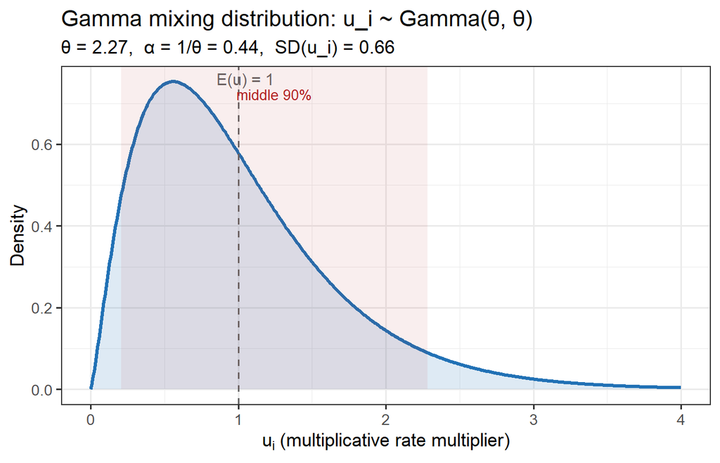

Gamma mixing distribution for the individual-level multiplier u_i. Each PhD student’s true rate is their predicted count μ_i multiplied by their u_i.

```r
u_seq <- seq(0, 4, length.out = 500)
u_df  <- data.frame(
  u       = u_seq,
  density = dgamma(u_seq, shape = shape_u, rate = rate_u)
)

ggplot(u_df, aes(x = u, y = density)) +
  geom_line(linewidth = 1.1, color = "#2171b5") +
  geom_area(alpha = 0.15, fill = "#2171b5") +
  geom_vline(xintercept = 1, linetype = "dashed", color = "grey40") +
  annotate("text", x = 1.05, y = Inf, vjust = 1.5,
           label = "E(u) = 1", color = "grey40", size = 4) +
  annotate("rect", xmin = lo, xmax = hi, ymin = 0, ymax = Inf,
           alpha = 0.08, fill = "firebrick") +
  annotate("text", x = (lo + hi) / 2, y = Inf, vjust = 3,
           label = "middle 90%", color = "firebrick", size = 3.5) +
  labs(
    title    = "Gamma mixing distribution: u_i ~ Gamma(θ, θ)",
    subtitle = sprintf("θ = %.2f,  α = 1/θ = %.2f,  SD(u_i) = %.2f",
                       theta_hat, alpha_hat, sqrt(alpha_hat)),
    x = expression(u[i] ~ "(multiplicative rate multiplier)"),
    y = "Density"
  ) +
  theme_bw(base_size = 13)
```

In plain language: *even after accounting for all predictors, individual publication rates vary by a factor with SD ≈ 0.66 around the model prediction.* A student at the 5th percentile of $u_i$ publishes at 0.21× their predicted rate; one at the 95th publishes at 2.28×.

## Variance inflation relative to Poisson

The variance inflation factor (VIF) relative to Poisson *depends on the mean* $\mu$:

$$\text{VIF}(\mu) =
\frac{\text{Var}(Y)}{\mu} = 1 + \frac{\mu}{\theta} = 1 +
\alpha\mu$$

```r
mu_vals <- c(1, 2, 4, 6, 10)
vif     <- 1 + alpha_hat * mu_vals

data.frame(mu = mu_vals, VIF = round(vif, 2),
           `Var(Y)` = round(vif * mu_vals, 2)) |>
  knitr::kable(caption = "Variance inflation at selected values of μ (PhdPubs NB fit)")
```

Variance inflation at selected values of μ (PhdPubs NB fit)

| mu | VIF | Var.Y. |
| --- | --- | --- |
| 1 | 1.44 | 1.44 |
| 2 | 1.88 | 3.76 |
| 4 | 2.76 | 11.06 |
| 6 | 3.65 | 21.88 |
| 10 | 5.41 | 54.11 |

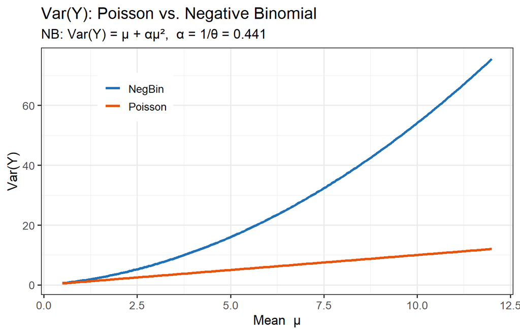

Variance of Y under Poisson (= μ) vs. negative binomial, as a function of the mean.

```r
mu_seq <- seq(0.5, 12, length.out = 200)
vif_df <- data.frame(
  mu       = mu_seq,
  Poisson  = mu_seq,
  NegBin   = mu_seq + alpha_hat * mu_seq^2
)

tidyr::pivot_longer(vif_df, -mu, names_to = "model", values_to = "variance") |>
  ggplot(aes(x = mu, y = variance, color = model)) +
  geom_line(linewidth = 1.1) +
  scale_color_manual(values = c(Poisson = "#e6550d", NegBin = "#2171b5")) +
  labs(
    title    = "Var(Y): Poisson vs. Negative Binomial",
    subtitle = sprintf("NB: Var(Y) = μ + αμ²,  α = 1/θ = %.3f", alpha_hat),
    x        = "Mean  μ",
    y        = "Var(Y)",
    color    = NULL
  ) +
  theme_bw(base_size = 13) +
  theme(legend.position = "inside", legend.position.inside = c(0.2, 0.8))
```

## Testing against Poisson: is overdispersion significant?

The likelihood-ratio test compares the NB log-likelihood to Poisson. Under $H_0: \theta \to \infty$ (no overdispersion), the test statistic is on the boundary of the parameter space, so the p-value is conservative (halved $\chi^2_1$).

```r
# LRT: NegBin vs Poisson
LRT  <- 2 * (logLik(phd.nbin) - logLik(phd.pois))
pval <- pchisq(LRT, df = 1, lower.tail = FALSE) / 2   # boundary correction

cat(sprintf("LRT statistic: %.2f  (df = 1)\n", LRT))
```

```
## LRT statistic: 179.97  (df = 1)
```

```r
cat(sprintf("p-value (boundary-corrected): %.2e\n", pval))
```

```
## p-value (boundary-corrected): 2.46e-41
```

```r
# AIC comparison
cat(sprintf("\nAIC — Poisson: %.1f,  NegBin: %.1f,  ΔAIC: %.1f\n",
            AIC(phd.pois), AIC(phd.nbin), AIC(phd.pois) - AIC(phd.nbin)))
```

```
##
## AIC — Poisson: 3313.3,  NegBin: 3135.4,  ΔAIC: 178.0
```

## Quick reference

| Quantity | Expression | PhdPubs estimate |
| --- | --- | --- |
| `theta` ($\theta$) | size / precision | 2.267 |
| `alpha` ($\alpha = 1/\theta$) | Var($u_i$) | 0.441 |
| SD of $u_i$ | $\sqrt{\alpha}$ | 0.664 |
| Poisson limit | $\theta \to \infty$, $\alpha \to 0$ | — |
| VIF at $\mu = 4$ | $1 + \alpha\mu$ | 2.76 |

The $\alpha$ parameterization (used by Stata, `pscl`, `countreg`) is more directly interpretable as an overdispersion quantity. The $\theta$ parameterization is more natural as the shape of the Gamma mixing distribution. Either way, the test $H_0: \theta \to \infty$ (i.e. $\alpha = 0$) is the test against Poisson.